# Organize code for model comparison and validation!

I wanted to show you how I organize my code to compare and validate different machine learning models

I'll explain this using the example of Linear Regression. The dataset that we're going to be using is called the **mpg** dataset.

It's generally a good practice to have all your imports at the top of your notebook. This helps people who're looking at your notebook to easily understand all the packages you'll be needing to run the notebook.

```python
import typing
from functools import partial
from sklearn.linear_model import LinearRegression, ElasticNet
from sklearn.metrics import r2_score
from sklearn.model_selection import train_test_split
from sklearn.preprocessing import StandardScaler
from typing_extensions import Protocol

import numpy as np
import plotnine as pn
import pandas as pd

from sklearn.linear_model.base import LinearModel

from plotnine.data import mpg
%matplotlib inline
```

The mpg dataset contains info collected by the US Environmental Protection Agency on 38 brands of cars.

Let's see if we can identify the different factors that affect the mileage of a car.

Do you think cars with bigger engines use more fuel than cars with smaller engines?

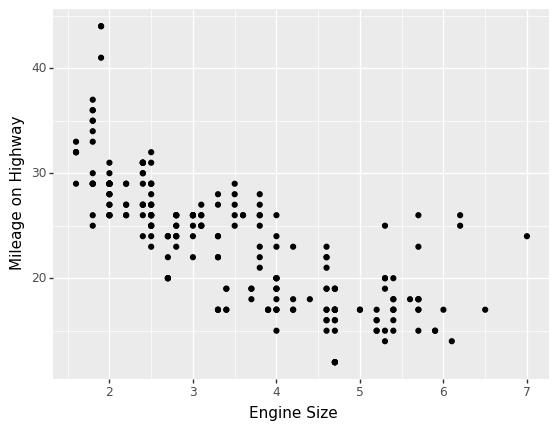

```python
(
    pn.ggplot(data=mpg) +
    pn.geom_point(mapping=pn.aes(x="displ", y="hwy")) +
    pn.xlab("Engine Size") +
    pn.ylab("Mileage on Highway")
)
```

What is happening to the mileage as the engine size is increasing?

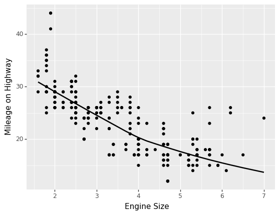

```python
(
    pn.ggplot(data=mpg, mapping=pn.aes(x="displ", y="hwy")) +
    pn.geom_point() +
    pn.geom_smooth(se=False) +
    pn.xlab("Engine Size") +
    pn.ylab("Mileage on Highway")
)
```

Let's try to fit our own line to the dataset.

Now a Data Scientist generally spends a majority of their time on "tidying" up the data. This involves dealing with missing data, corrupted data, munging data from different sources into a single table and so on. Since I'm not focusing on that in today's talk, I'm going to start with a dataset that I've already preprocessed.

```python
automobile_df = pd.read_csv('data/auto_mpg_processed.csv')
print(automobile_df.head())
```

```
    mpg  cylinders  displacement  horsepower  weight  acceleration  Age
0  30.0          4         111.0        80.0    2155          14.8   42
1  14.0          8         318.0       150.0    4077          14.0   47
2  30.0          4         146.0        67.0    3250          21.8   39
3  13.0          8         400.0       175.0    5140          12.0   48
4  17.5          8         318.0       140.0    4080          13.7   41
```

What is the structure of our code going to look like?

```python
class ModelData(typing.NamedTuple):
    inputs: np.ndarray
    targets: np.ndarray


class DataSplits(typing.NamedTuple):
    train: ModelData
    test: ModelData


# Generate training and testing data
class TrainValSplitFn(Protocol):
    """ This is the API that the function for generating the training and validation
    splits

    """
    def __call__(self, data: ModelData) -> DataSplits:
        raise NotImplementedError

# Any data transformation
class TransformDataFn(Protocol):
    """ Any data transformation we do will be using a function with this API.

    Such a data transformation function would just take in the input data (X) and return
    a transformed copy of the data.

    NOTE: Do NOT modify the input data. Create a copy and modify it instead. In general,
    it's better to keep our functions devoid of any side effects. Modifying the inputs
    of a function, modifying the file system etc are examples of side effects. Functions
    which do not have any side effects are called "pure" functions.
    """
    def __call__(self, data: ModelData) -> ModelData:
        raise NotImplementedError

# Fit model
class FitModelFn(Protocol):
    """ All our models will follow this API.

    Our models are going to be functions that take in the train and test data frames,
    and return a learned LinearModel.
    """
    def __call__(self, data: ModelData) -> LinearModel:
        raise NotImplementedError


# Generate validation metrics
class ValidationMetrics(typing.NamedTuple):
    """ The set of metrics that we're interested in when comparing different models. """
    test_score: float
    training_score: float


class ValidationMetricsFn(Protocol):
    """ Function that generates the metrics for validating the model performance. """
    def __call__(self, model: LinearModel, data: DataSplits) -> ValidationMetrics:
        raise NotImplementedError


class PlotFn(Protocol):
    """ Function that does any required plotting for us. """
    def __call__(self, model: LinearModel, data: DataSplits) -> typing.Any:
        raise NotImplementedError
```

Let's generate the train test splits for our data

```python
def ensure_2d(data: ModelData) -> ModelData:
    """ If the data has less than 2 dims, expand it to at least 2D. """
    return ModelData(
        inputs=data.inputs.reshape(-1, 1), targets=data.inputs.reshape(-1, 1)
    )


def standard_scaling_data_transform(data: ModelData) -> ModelData:
    """ """
    pre_processor = StandardScaler()
    return ModelData(
        inputs=pre_processor.fit_transform(data.inputs),
        targets=data.targets
    )


def dummy_data_transform(data: ModelData) -> ModelData:
    """ Returns data as is. Useful for passing in as a default data transform when you
    don't want to do any data transformation.

    """
    return data


def dummy_plot(model: LinearModel, data: ModelData) -> None:
    pass


def simple_validation(model: LinearModel, data: DataSplits) -> ValidationMetrics:
    predictions = model.predict(data.test.inputs)
    training_score = model.score(data.train.inputs, data.train.targets)
    test_score = r2_score(data.test.targets, predictions)
    return ValidationMetrics(test_score=test_score, training_score=training_score)


def create_data_splits(
    data_frame: pd.DataFrame,
    input_columns: typing.List[str],
    target_column: str,
    test_size: float = 0.2,
    data_transform: TransformDataFn = dummy_data_transform,
) -> DataSplits:
    model_data = ModelData(
        inputs=data_frame[input_columns].values,
        targets=data_frame[target_column].values,
    )
    transformed_data = data_transform(model_data)
    x_train, x_test, y_train, y_test = train_test_split(
        transformed_data.inputs, transformed_data.targets, test_size=test_size
    )
    return DataSplits(
        train=ModelData(x_train, y_train), test=ModelData(x_test, y_test)
    )
```

Now that we've defined the structure of helper functions, let's use them to write the function that is going to go through the transformation, training and validation loop and report the results for us. We can then use this function for every new model that we want to test.

```python
def try_model(
    model_trainer: FitModelFn,
    data_frame: pd.DataFrame,
    input_columns: typing.List[str],
    target_column: str,
    validation_fn: ValidationMetricsFn,
    plot_fn: PlotFn = dummy_plot,
    test_size: float = 0.2,
    data_transform: TransformDataFn = dummy_data_transform,
):
    """  """
    model_data = ModelData(
        inputs=data_frame[input_columns].values,
        targets=data_frame[target_column].values,
    )
    transformed_data = data_transform(model_data)
    x_train, x_test, y_train, y_test = train_test_split(
        transformed_data.inputs, transformed_data.targets, test_size=test_size
    )
    data = DataSplits(
        train=ModelData(x_train, y_train), test=ModelData(x_test, y_test)
    )
    model = model_trainer(data.train)
    print(plot_fn(model, data))
    return validation_fn(model, data)
```

And let's throw in some plotting functions

```python
def plot_predictions_vs_targets(model: LinearModel, data: DataSplits) -> pn.ggplot:
    data_frame = pd.DataFrame.from_dict(
        dict(
            inputs=data.test.inputs.flat,
            targets=data.test.targets.flat,
            predictions=model.predict(data.test.inputs).flat
        )
    )
    return (
        pn.ggplot(data=data_frame) +
        pn.geom_point(mapping=pn.aes(x="inputs", y="targets"), color="blue") +
        pn.geom_point(mapping=pn.aes(x="inputs", y="predictions"), color="green")
    )
```

Let's compare some models now!!!

```python
split_data = create_data_splits(
    data_frame=automobile_df,
    input_columns=["weight"],
    target_column="mpg",
)
```

```python
def linear_reg(data: ModelData) -> LinearRegression:
    x_train, y_train = data
    model = LinearRegression(normalize=True)
    model.fit(x_train,y_train)

    return model
```

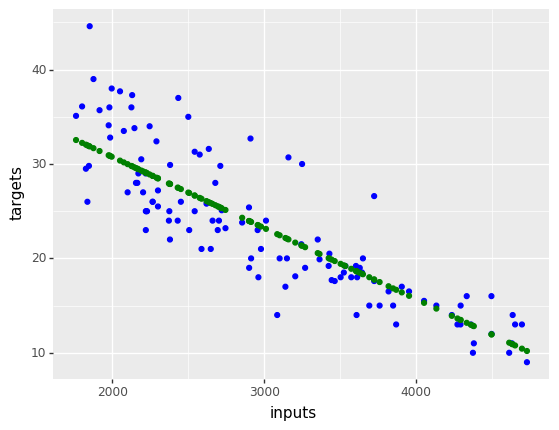

```
ValidationMetrics(test_score=0.7417882027886584, training_score=0.6717037781010815)
```

```python
linear_regression_metrics = try_model(
    model_trainer=linear_reg,
    data_frame=automobile_df,
    input_columns=["weight"],
    target_column="mpg",
    validation_fn=simple_validation,
    plot_fn=plot_predictions_vs_targets,
    test_size=0.3,
)
print(linear_regression_metrics)
```

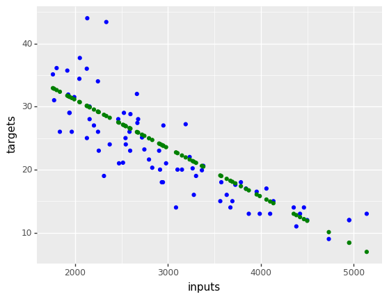

```
ValidationMetrics(test_score=0.6997495113780463, training_score=0.6898025462413752)
```

```python
def elastic_net_reg(
    data: ModelData,
    alpha = 1,
    l1_ratio = 0.5,
    max_iter = 100000,
    warm_start = True
) -> ElasticNet:
    x_train, y_train = data
    model = ElasticNet(alpha = alpha,l1_ratio = l1_ratio, max_iter = max_iter, warm_start = warm_start)
    model.fit(x_train,y_train)

    return model


elastic_net_regression_metrics = try_model(
    model_trainer=partial(elastic_net_reg, alpha=0, l1_ratio=0.5),
    data_frame=automobile_df,
    input_columns="weight".split(),
    target_column="mpg",
    validation_fn=simple_validation,
    plot_fn=plot_predictions_vs_targets,
)

print(elastic_net_regression_metrics)
```